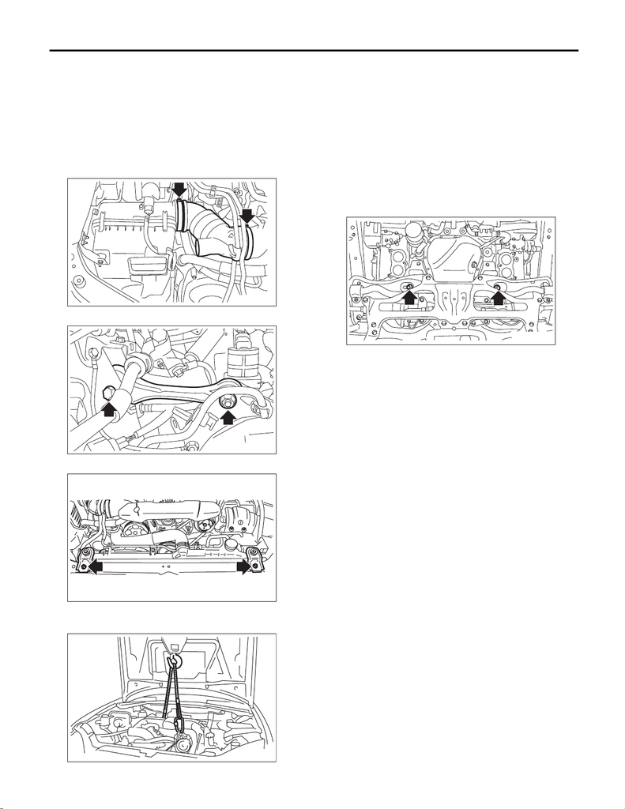

LU(STI)-18

Oil Pan and Strainer

LUBRICATION

5. Oil Pan and Strainer

A: REMOVAL

1) Disconnect the ground cable from battery.

2) Remove the air intake duct. <Ref. to IN(STI)-11,

REMOVAL, Air Intake Duct.>

3) Remove the intercooler. <Ref. to IN(STI)-13,

REMOVAL, Intercooler.>

4) Remove the air intake boot.

5) Remove the pitching stopper.

6) Remove the radiator upper brackets.

7) Support the engine with a lifting device and wire

ropes.

8) Lift up the vehicle.

CAUTION:

When lifting up the vehicle, raise up wire ropes

at the same time.

9) Remove the under cover. <Ref. to EI-21, RE-

MOVAL, Front Under Cover.>

10) Drain the engine oil. <Ref. to LU(STI)-11, RE-

PLACEMENT, Engine Oil.>

11) Remove the front exhaust pipe. <Ref. to

EX(STI)-5, REMOVAL, Front Exhaust Pipe.>

12) Remove the nuts which secure the engine

mounting to the front crossmember.

13) Remove the bolts which secure oil pan on cyl-

inder block with the engine raised up.

14) Insert an oil pan cutter blade between cylinder

block-to-oil pan clearance and remove the oil pan.

CAUTION:

Do not use a screwdriver or similar tool in place

of oil pan cutter.

15) Remove the oil strainer.

ME-08020

CO-03369

LU-00222

LU-03187

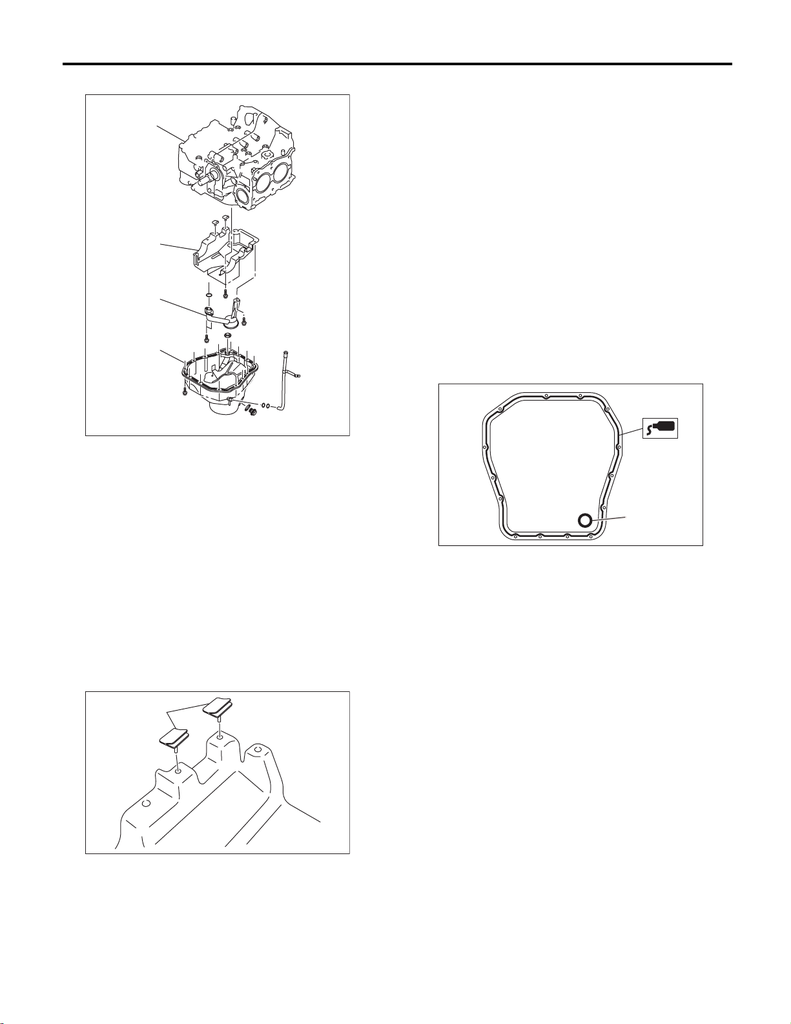

LU(STI)-19

Oil Pan and Strainer

LUBRICATION

16) Remove the baffle plate.

B: INSTALLATION

NOTE:

Before installing the oil pan, clean the mating sur-

face of oil pan and engine block.

1) Make sure that the seals (A) are installed se-

curely on the baffle plate in a direction as shown in

the figure below.

NOTE:

Use a new seal.

2) Install the baffle plate.

Tightening torque:

6.4 N·m (0.7 kgf-m, 4.7 ft-lb)

3) Install the oil strainer to cylinder block.

NOTE:

Use new O-rings.

Tightening torque:

10 N·m (1.0 kgf-m, 7.4 ft-lb)

4) Tighten the oil strainer stay together with the baf-

fle plate.

Tightening torque:

6.4 N·m (0.7 kgf-m, 4.7 ft-lb)

5) Apply liquid gasket to the mating surfaces of oil

pan, and install the oil pan.

NOTE:

• Use a new gasket.

• Install within 5 min. after applying liquid gasket.

Liquid gasket:

THREE BOND 1217G (Part No. K0877Y0100)

or equivalent

(A) Oil pan

(B) Oil strainer

(C) Baffle plate

(D) Cylinder block

(C)

(D)

(B)

LU-02334

LU-00052

(A)

(A) Gasket

LU-02353

(A)

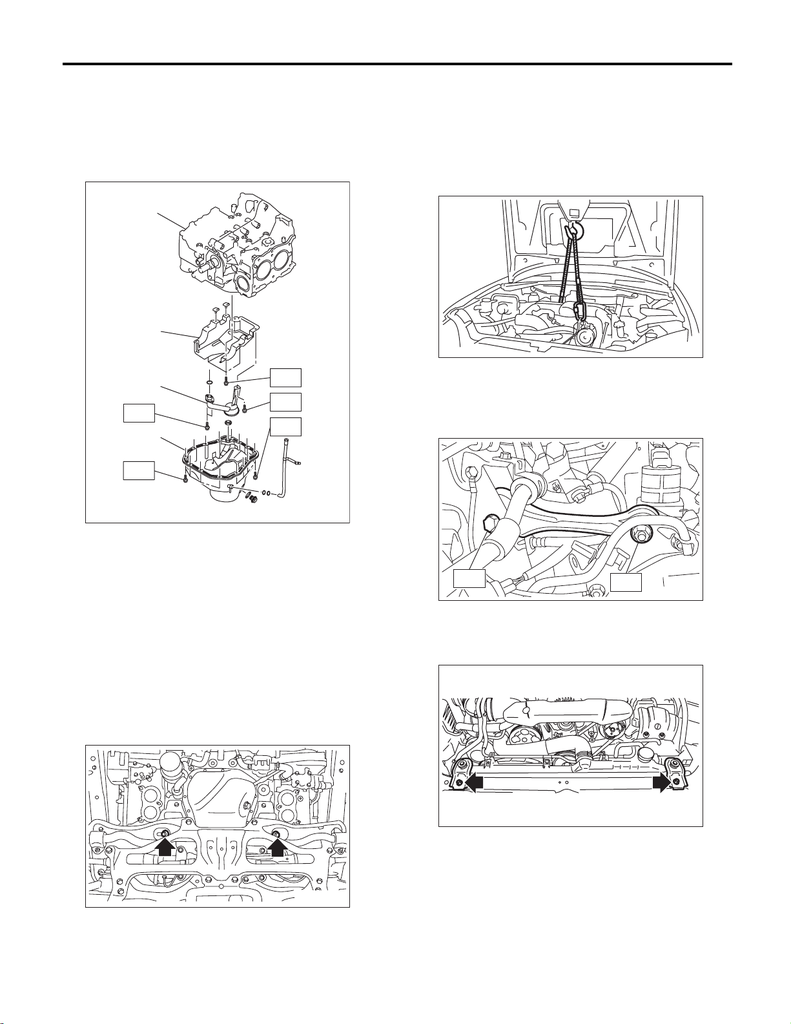

LU(STI)-20

Oil Pan and Strainer

LUBRICATION

6) Tighten the bolts which install oil pan to cylinder

block.

Tightening torque:

T1: 5 N·m (0.5 kgf-m, 3.7 ft-lb)

T2: 6.4 N·m (0.7 kgf-m, 4.7 ft-lb)

T3: 10 N·m (1.0 kgf-m, 7.4 ft-lb)

7) Lower the engine onto front crossmember.

8) Install the nuts which hold the engine mounting

to the front crossmember.

NOTE:

Use a new nut.

Tightening torque:

60 N·m (6.1 kgf-m, 44.3 ft-lb)

9) Install the front exhaust pipe. <Ref. to EX(STI)-5,

INSTALLATION, Front Exhaust Pipe.>

10) Install the under cover. <Ref. to EI-22, INSTAL-

LATION, Front Under Cover.>

11) Lower the vehicle.

CAUTION:

When lowering the vehicle, lower the lift up de-

vice and wire ropes at the same time.

12) Remove the lifting device and wire ropes.

13) Install the pitching stopper.

Tightening torque:

T1: 50 N·m (5.1 kgf-m, 36.9 ft-lb)

T2: 58 N·m (5.9 kgf-m, 42.8 ft-lb)

14) Install the radiator upper brackets.

Tightening torque:

12 N·m (1.2 kgf-m, 8.9 ft-lb)

(A) Oil pan

(B) Oil strainer

(C) Baffle plate

(D) Cylinder block

T2

T3

T1

(A)

(C)

(D)

(B)

T1

LU-02335

LU-03187

LU-00222

ME-08021

T2

T1

CO-03369

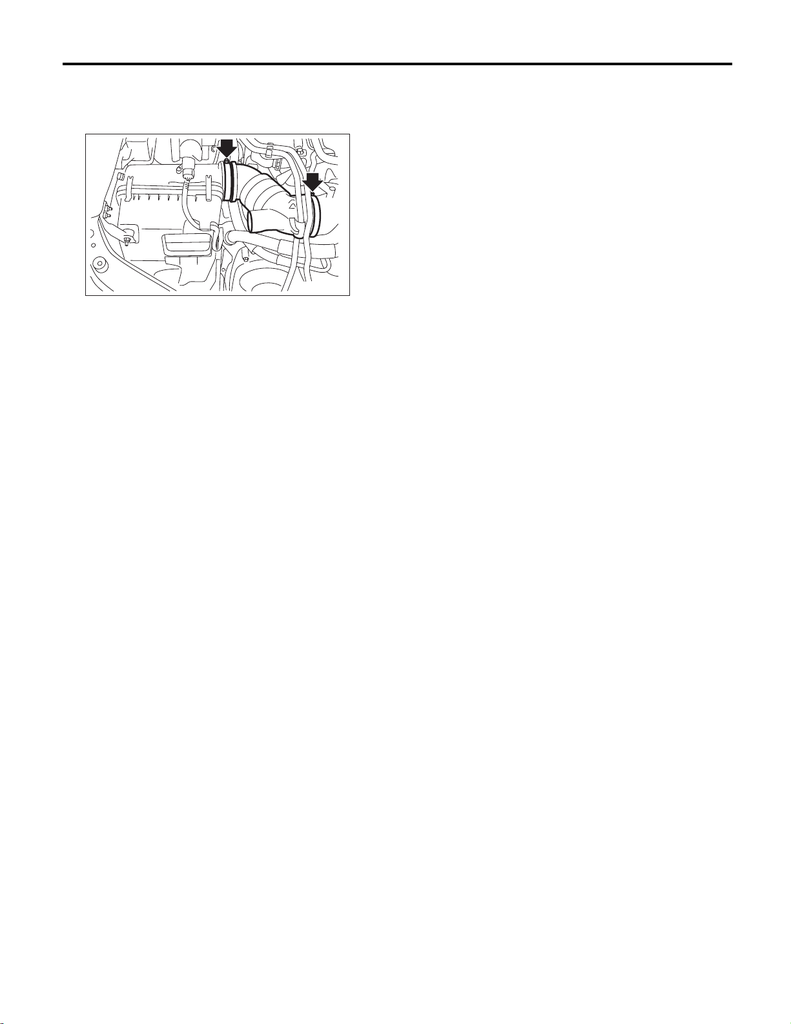

LU(STI)-21

Oil Pan and Strainer

LUBRICATION

15) Install the air intake boot.

Tightening torque:

2.5 N·m (0.3 kgf-m, 1.8 ft-lb)

16) Install the intercooler. <Ref. to IN(STI)-14, IN-

STALLATION, Intercooler.>

17) Install the air intake duct. <Ref. to IN(STI)-11,

INSTALLATION, Air Intake Duct.>

18) Connect the battery ground terminal.

19) Refill the engine oil. <Ref. to LU(STI)-11, RE-

PLACEMENT, Engine Oil.>

C: INSPECTION

Check that the oil pan, oil strainer and baffle plate

do not have deformation, cracks or damage.

IN-03564